# Exam Performance Analysis: Gender and Time Patterns

This notebook analyzes exam performance differences between male and female students, focusing on:

- **Performance differences** between genders with statistical testing
- **Time completion patterns** by gender
- **Effect size** and practical significance of observed differences
- **Time-performance correlations** and their relationship to gender

## 1. Data Loading

The cleaned exam data is loaded from the CSV file.

```
Data loaded successfully from ../data/cleaned_data/IN1020_2023_cleaned_data.csv
```

## Overview

```
This notebook provides a comprehensive analysis of exam performance for IN1020_2023, comparing male and female students.
```

## 2. Data Preparation

We'll prepare separate datasets for different analyses:

- **df_male**: Data about total score among male students
- **df_female**: Data about total score among female students
- **df_time**: Data including exam timing information by gender

```
Dataset with only male students:
```

|  | student_id | gender | total_score |
| --- | --- | --- | --- |
| 0 | 1 | M | 69.33 |
| 5 | 6 | M | 71.83 |
| 9 | 10 | M | 63.00 |
| 10 | 11 | M | 56.50 |
| 13 | 14 | M | 88.86 |

```
Dataset with only female students:
```

|  | student_id | gender | total_score |
| --- | --- | --- | --- |
| 1 | 2 | F | 68.5 |
| 2 | 3 | F | 67.0 |
| 3 | 4 | F | 48.0 |
| 4 | 5 | F | 70.0 |
| 6 | 7 | F | 27.0 |

```
Dataset with time taken to complete the exam:
```

|  | student_id | exam_start_time | exam_end_time | gender | total_score | extra_time_mins | incident_time_mins | time_taken |
| --- | --- | --- | --- | --- | --- | --- | --- | --- |
| 0 | 1 | 2023-12-11 08:00:04 | 2023-12-11 11:50:07 | M | 69.33 | 0 | 0 | 230.05 |
| 1 | 2 | 2023-12-11 08:00:02 | 2023-12-11 12:29:29 | F | 68.50 | 0 | 0 | 269.45 |
| 2 | 3 | 2023-12-11 08:00:02 | 2023-12-11 11:51:38 | F | 67.00 | 0 | 0 | 231.60 |
| 3 | 4 | 2023-12-11 08:00:07 | 2023-12-11 11:41:39 | F | 48.00 | 0 | 0 | 221.53 |
| 4 | 5 | 2023-12-11 08:00:08 | 2023-12-11 11:58:49 | F | 70.00 | 0 | 0 | 238.68 |

## 3. Descriptive Statistics

This section presents comprehensive statistical measures for total scores by gender, including:

- Central tendency measures (mean, median, mode)
- Dispersion measures (standard deviation, range, IQR)
- Distribution shape indicators (skewness, kurtosis)
- Gender performance comparison

```
=== DESCRIPTIVE STATISTICS FOR TOTAL SCORES ===
             Male   Female
Count     327.000  263.000
Mean       66.440   61.050
Median     66.500   61.660
Mode       62.500   55.000
Std Dev    12.860   13.290
Min        19.500   21.150
Max        95.500   90.160
Q1         59.140   51.250
Q3         76.130   71.250
IQR        16.980   20.000
Skewness   -0.487   -0.294
Kurtosis    0.281   -0.238

=== KEY FINDINGS ===
Mean difference (Male - Female): 5.39 points
Percentage difference: 8.8%
Male performance is higher than female performance
```

### 3.1 Gender Distribution

The following pie chart shows the proportion of male and female students in the exam.

[figure not shown]

## 4. Statistical Analysis

This section performs statistical hypothesis testing to determine if performance differences between genders are statistically significant and practically meaningful.

### 4.1 Score Distribution Visualization

This section visualizes the score distributions for male and female students with key statistical measures overlaid:

- **Red dashed line**: Mean score
- **Green solid line**: Median score
- **Purple shaded area**: ±1 standard deviation from the mean
- **Skewness value**: Indicates distribution shape

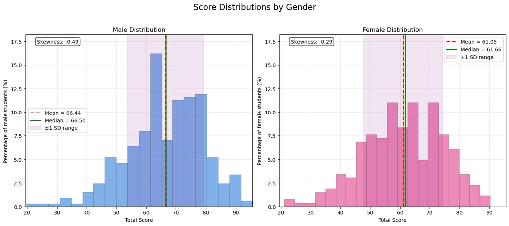

```
=== DISTRIBUTION SHAPE INTERPRETATION ===
Male: approximately symmetric (skewness = -0.487)
Female: approximately symmetric (skewness = -0.294)
```

### 4.2 Data Distribution & Normality Testing

Before choosing the appropriate statistical test, we need to check if the data follows a normal distribution.

```
=== NORMALITY TESTS ===

Male (n=327):
  Shapiro-Wilk test for samples between 200 and 2000 entities: W=0.9832, p=0.0007
  Normal distribution: False

Female (n=263):
  Shapiro-Wilk test for samples between 200 and 2000 entities: W=0.9902, p=0.0727
  Normal distribution: True

Both groups normally distributed: False
```

### 4.3 Hypothesis Testing

The following analysis tests whether the observed performance difference between male and female students is statistically significant and calculates effect sizes to determine practical importance.

```
=== STATISTICAL HYPOTHESIS TESTING ===
H0: No difference in mean scores between male and female students
H1: There is a difference in mean scores between groups

Primary approach: Non-parametric (based on normality test results)

NON-PARAMETRIC APPROACH (Data violates normality assumptions):
  Mann-Whitney U test: U = 53101.0, p = 0.0000
  Rank-biserial correlation: 0.2349
  Effect size magnitude: small
  Significant at α=0.05: True

CORRELATION ANALYSIS:
  Point-biserial correlation: r = 0.2013, p = 0.0000
  Variance explained (R²): 0.0405 (4.1%)

PRIMARY INTERPRETATION:
  Based on Mann-Whitney U test:
  Statistical significance: Yes (p = 0.0000)
  Effect size: Rank-biserial r = 0.235 (small)
  Practical significance: Yes
  Decision: Reject H0 - There is a statistically significant difference between groups
```

### 4.4 Results Interpretation

The following interpretation explains the statistical findings in accessible language:

```
UNDERSTANDING YOUR TEST RESULTS
======================================================================

 WHAT WE FOUND:
   • Male students averaged: 66.4 points
   • Female students averaged: 61.1 points
   • Difference: 5.4 points (male students scored higher)

 QUESTION 1: Is this difference REAL or just random chance?
   ANSWER: We are extremely confident (99.9%+ certain)
   What this means: This is almost definitely a real difference, not random variation.
   Technical note: p-value = 0.0000

 QUESTION 2: How BIG or IMPORTANT is this difference?
   ANSWER: SMALL - noticeable but minor
   Suggested action: Worth monitoring but probably doesn't require immediate intervention.

QUESTION 3: What does this mean in PRACTICAL terms?
   • The male group scores about 8.8% higher on average
   • Individual students can still perform very differently from their group average

SUMMARY:
   STATISTICALLY SIGNIFICANT BUT PRACTICALLY SMALL
   There IS a real difference, but it's so small it may not matter educationally.
   Recommendation: Monitor future data but don't overreact to this small difference.

======================================================================
```

### 4.5 Distribution Visualization & Outlier Detection

The following visualizations help identify outliers and understand the distribution shape through boxplots and violin plots.

```
=== OUTLIER ANALYSIS ===
Male: 5 outliers (1.5%)
  Range: 19.50 - 32.00
Female: 1 outliers (0.4%)
  Range: 21.15 - 21.15
```

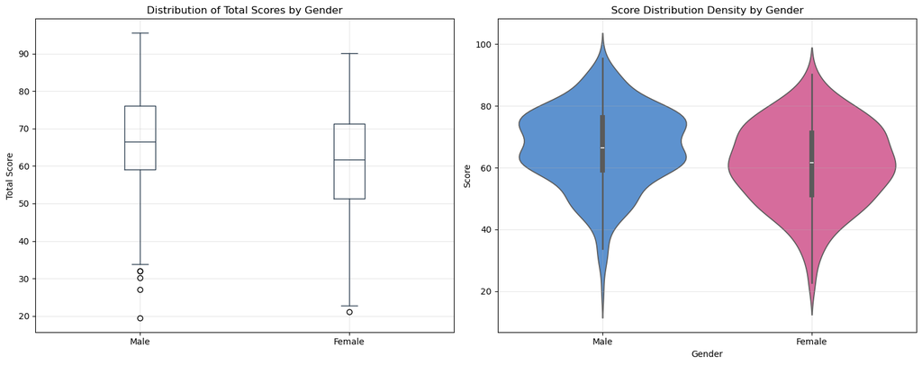

## 5. Time-Performance Correlation Analysis

This section examines the relationship between time spent on the exam and performance, analyzing:

- Overall correlation between time and scores
- Gender-specific time-score relationships
- Statistical significance and practical implications

### 5.1 Correlation Analysis

```
=== TIME-SCORE CORRELATION ANALYSIS ===

Testing normality for Time taken and Total score:

Time taken (n=590):
  Shapiro-Wilk test for samples between 200 and 2000 entities: W=0.8633, p=0.0000
  Normal distribution: False

Total score (n=590):
  Shapiro-Wilk test for samples between 200 and 2000 entities: W=0.9876, p=0.0001
  Normal distribution: False

Both variables normally distributed: False

Using NON-PARAMETRIC approach (Spearman correlation):
  Spearman correlation: ρ = -0.0844, p = 0.0403
  Pearson correlation (supplementary): r = -0.0360, p = 0.3825

PRIMARY INTERPRETATION (Spearman correlation):
  Correlation strength: negligible negative correlation
  Statistical significance: Yes (p = 0.0403)

=== GENDER-SPECIFIC CORRELATIONS ===

Testing normality for Male time taken and Male total score:

Male time taken (n=327):
  Shapiro-Wilk test for samples between 200 and 2000 entities: W=0.8949, p=0.0000
  Normal distribution: False

Male total score (n=327):
  Shapiro-Wilk test for samples between 200 and 2000 entities: W=0.9832, p=0.0007
  Normal distribution: False

Both variables normally distributed: False

Testing normality for Female time taken and Female total score:

Female time taken (n=263):
  Shapiro-Wilk test for samples between 200 and 2000 entities: W=0.8102, p=0.0000
  Normal distribution: False

Female total score (n=263):
  Shapiro-Wilk test for samples between 200 and 2000 entities: W=0.9902, p=0.0727
  Normal distribution: True

Both variables normally distributed: False

Gender-specific results:
  Male (Spearman): ρ = -0.0415, p = 0.4550
  Female (Spearman): ρ = -0.0319, p = 0.6063
```

### 5.2 Correlation Results Interpretation

The following interpretation explains the time-score relationship findings in accessible language:

[output not shown]

### 5.3 Time Analysis Visualizations

The following visualizations examine time usage patterns by gender and their relationship with exam performance.

#### 5.3.1 Time Statistics by Gender

```
=== TIME ANALYSIS DESCRIPTIVE STATISTICS ===
             Male   Female
Count     327.000  263.000
Mean      194.970  219.360
Median    208.000  235.380
Mode      240.050  239.530
Std Dev    46.390   36.520
Min        44.580   93.200
Max       271.180  300.670
Q1        164.180  207.980
Q3        236.340  239.860
IQR        72.160   31.880
Skewness   -0.800   -1.474
Kurtosis   -0.328    2.027
```

#### 5.3.2 Time Distribution and Time-Score Relationship Plots

The following visualizations provide different perspectives on time usage:

1. **Boxplot**: Time distribution by gender with outlier identification
2. **Scatter plot**: Time vs score relationship by gender

```
=== TIME OUTLIER ANALYSIS ===
Male Time: 1 outliers (0.3%)
  Range: 44.58 - 44.58
Female Time: 27 outliers (10.3%)
  Range: 93.20 - 300.67
```

[figure not shown]